# This code simulates cod populations at different k slopes.

### 3. Run simulations (age-structure with density dependence)

#### We now have modified Leslie matricies for each population at different k values. Let’s run simulations. There are two ways to simulate: 1) use the age-structured model with BH density dependence to simulate population abundance over time, and 2) use the modified Leslie matrix to simulate deviations from equilibrium (aka linearized around the equilibirum). First use the age-structure model with BH density dependence.

```r
timesteps = 1000
rm_first_timesteps = 100 #remove transitory effects for spectral analysis
alpha = 100 #constant for all pops and k values
beta = 1000 #constant for all pops and k values
initial_eggs = 1000
sig_r = 0.1
span.multiplier = 1 # what is this again? something to do with spec.pgram
```

#### The code below simulates each population, at each k value, using ‘sim_model’ a function I wrote in simulation_model_cod_v3.r (see that script for details). The important output from sim_model is 2 vectors: timeseries of eggs and recruits.

```r
freq = seq(from=0.001111111, to=0.5, by=0.001111111) #all frequencies, for plotting later
output.spec.3dList = as.list(rep(NA,length(A3dlist))) #list of spec output for each pop

raw.3dList = as.list(rep(NA,length(A3dlist))) #list of timeseries output for each pop
names(raw.3dList) = names(A3dlist) #add names

# setting 'span' - a vector of odd integers to specify the smoothers
tmp <- ceiling(sqrt(length(1:(timesteps-rm_first_timesteps-1)))) #square root of timeseries length, rounded
if (tmp %% 2 == 0) {m <- tmp+1} else {m <- tmp} #make it odd, if the square root is even
m = m * span.multiplier

for (y in 1:length(A3dlist)) { #for pop y
  A3d = A3dlist[[y]] #choose the 3d array of matricies, use these to simulate below

  outputL.raw = as.list(rep(NA,length(ks))) #create temp empty list for storing output at each k
  outputL.spec = as.list(rep(NA,length(ks)))#create temp empty list for storing output at each k

  for (k in 1:length(ks)) { #for each k value

    A = A3d[,,k] #choose the Leslie matrix for this k value

    output = sim_model(A=A, timesteps=timesteps, #simulate
                       alpha=alpha, beta=beta,
                       sig_r=sig_r, initial_eggs=initial_eggs)
    outputL.raw[[k]] = do.call(cbind,output[c(2,3)]) #save sim output for each pop

    # --- do the spectral analysis
    spec_all = matrix(NA,nrow=length(freq),ncol=2) # matrix to store spec of egg, recruits

    #extract simulation of egg timeseries from model output
    spec_egg = spec.pgram(x=output[[2]][rm_first_timesteps:(timesteps-2)],
                          spans=c(m,m),plot = FALSE)
    spec_all[,1] <- spec_egg$spec #save spec output for plotting pops together, Helen Wearing says to multiply by 2

    #extract sim of recruits
    spec_rec = spec.pgram(x=output[[3]][rm_first_timesteps:(timesteps-2)],
                          spans=c(m,m),plot = FALSE)
    spec_all[,2] = spec_rec$spec #save spec output for plotting pops together, Helen Wearing says to multiply by 2

    outputL.spec[[k]] = spec_all
  }
  output.spec.3d = array(unlist(outputL.spec),dim=c(length(freq),length(spec_all[1,]),length(ks)))
  output.spec.3dList[[y]] = output.spec.3d #store array
  output.raw.3d = array(unlist(outputL.raw), dim=c(length(outputL.raw[[1]][,1]),2,length(ks)))
  raw.3dList[[y]] = output.raw.3d
}

# convert this into a dataframe
names(output.spec.3dList) = names(A3dlist)
# for each pop, 3d object: 3 rows=eggs/rec/adu, col=spec output, stack=diff k
```

### 4. Plot timeseries to make sure things are looking good.

#### Try plotting the egg or recruit timeseries at different k values for individual populations. First, transform raw.3dList into a df for plotting. I use ‘raw’ to indicate timeseries data (vs spec output).

```r
rawpoplist = as.list(rep(NA,length(raw.3dList)))
names(rawpoplist) <- names(raw.3dList)

for (e in 1:length(raw.3dList)) { #for each pop
  a = raw.3dList[[e]] #convert one pop array to df at a time

  rawlist = as.list(rep(NA,length(ks))) #placeholder for storing spec output at k

  for (k in 1:length(ks)) { #for each k, convert sim output into df

    rawout = as.data.frame(a[,,k]) #choose simout for each k
    names(rawout) = c("eggs","recruits")
    rawout$timesteps = seq(from=1,to=length(rawout$eggs),by=1)
    rawlong = melt(rawout,id.vars="timesteps")
    names(rawlong) <- c("timesteps","out.type","value")
    rawlong$kval <- rep(ks[k],length=length(rawlong$timesteps))
    rawlist[[k]] = rawlong #store sim output df for each k
  }
  df <- ldply(rawlist, data.frame)
  df$codNames <- rep(codNames[e],length=length(df$timesteps))
  rawpoplist[[e]] = df
}
rm(df,rawout,rawlong,rawlist)
raw.out.df <- ldply(rawpoplist, data.frame)
raw.out.df$kval <- factor(raw.out.df$kval)
raw.out.df$codNames <- factor(raw.out.df$codNames)
#Merge temp, peak spawning age, CV of spawning biomass distribution into df
#May be useful for plotting
raw.out.df <- merge(raw.out.df,eigentable[c("codNames","temp")],all.x=TRUE)
raw.out.df <- merge(raw.out.df,eigentable[c("codNames","mode_age")],all.x=TRUE)
raw.out.df <- merge(raw.out.df,eigentable[c("codNames","sd_mode")],all.x=TRUE)
raw.out.df <- merge(raw.out.df,eigentable[c("codNames","max_ages")],all.x=TRUE)
raw.out.df <- merge(raw.out.df,eigentable[c("codNames","cvs_mode")],all.x=TRUE)
raw.out.df <- mutate(raw.out.df, codNames = reorder(codNames, mode_age))#order plots by peak spawning age
```

#### Plot timeseries 8 of the 16 pops. Too hard to see if I plot all.

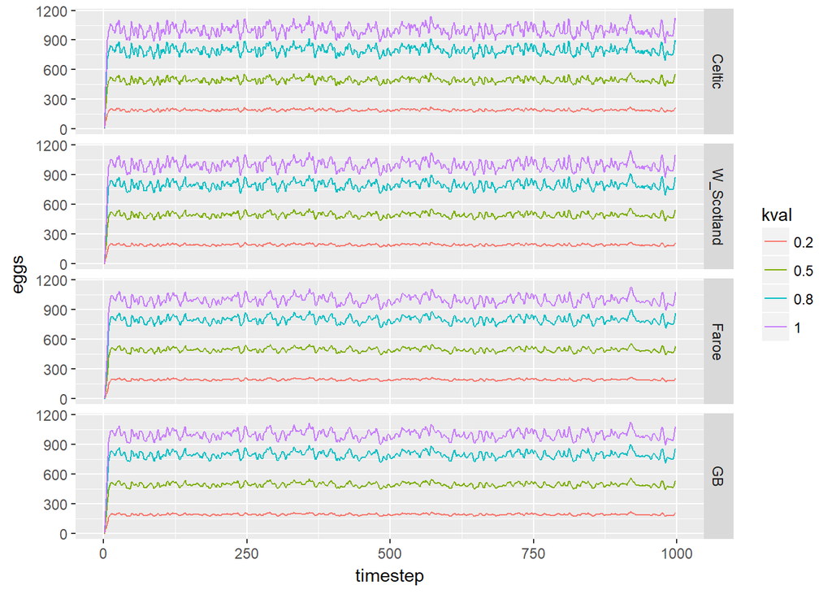

```r
# Plot eggs
ggplot(raw.out.df[raw.out.df$out.type == "eggs" & raw.out.df$codNames %in% c("Celtic","W_Scotland","Faroe","GB"),],
            aes(x=timesteps,y=value,group=kval)) +
  geom_line(aes(color=kval)) +
  facet_grid(codNames~.) +
  labs(x="timestep",y="eggs")
```

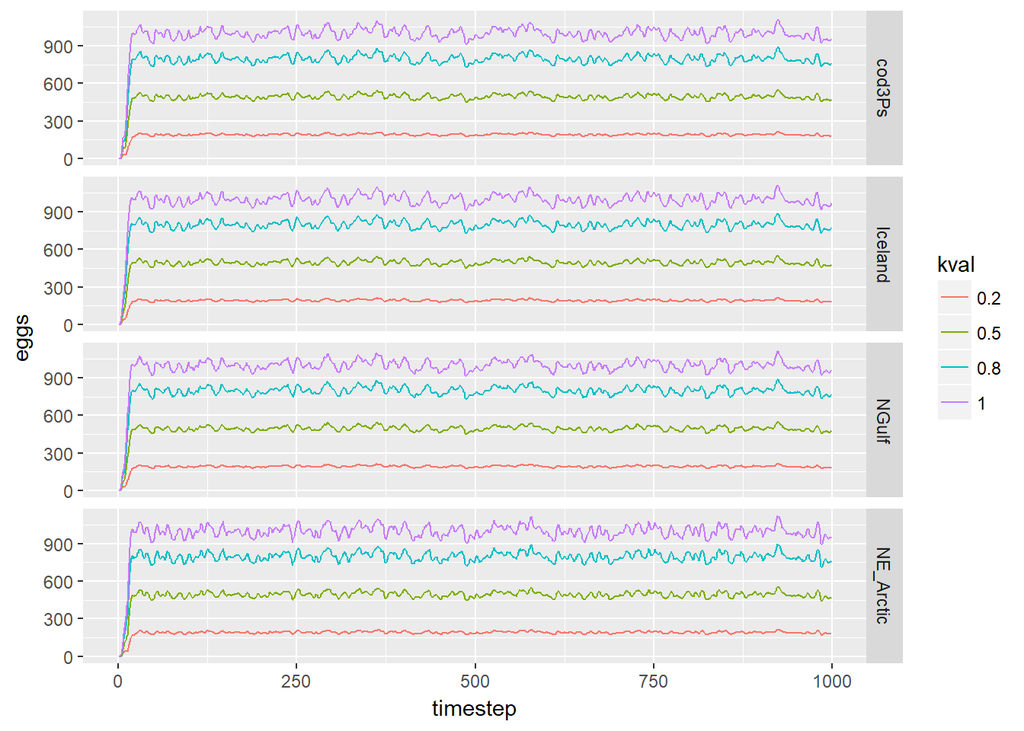

```r
ggplot(raw.out.df[raw.out.df$out.type == "eggs" & raw.out.df$codNames %in% c("cod3Ps","Iceland","NGulf","NE_Arctic"),],
            aes(x=timesteps,y=value,group=kval)) +
  geom_line(aes(color=kval)) +
  facet_grid(codNames~.) +
  labs(x="timestep",y="eggs")
```

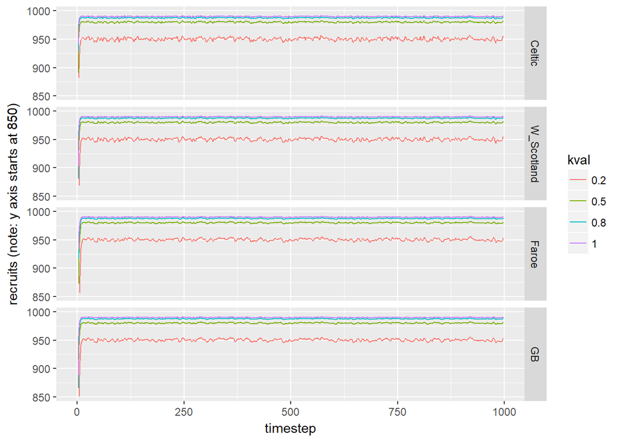

```r
# Plot recruits
ggplot(raw.out.df[raw.out.df$out.type == "recruits" & raw.out.df$codNames %in% c("Celtic","W_Scotland","Faroe","GB"),],
            aes(x=timesteps,y=value,group=kval)) +
  geom_line(aes(color=kval)) +
  facet_grid(codNames~.) +
  labs(x="timestep",y="recruits (note: y axis starts at 850)") +
  scale_y_continuous(limits = c(850, 1000))
```

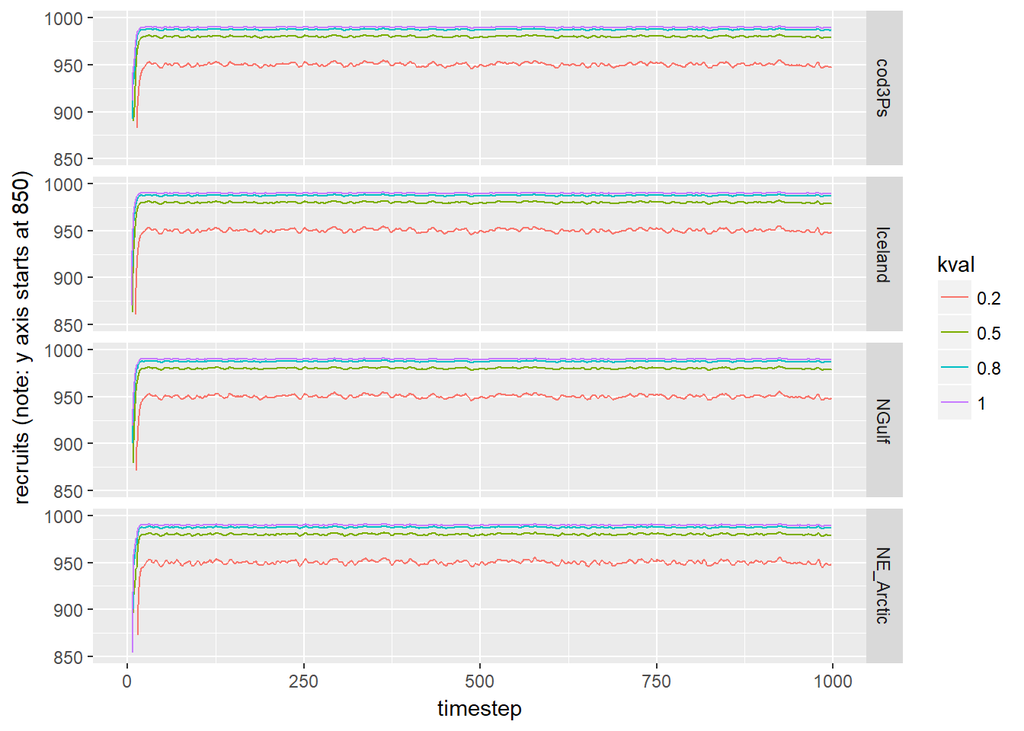

```r
ggplot(raw.out.df[raw.out.df$out.type == "recruits" & raw.out.df$codNames %in% c("cod3Ps","Iceland","NGulf","NE_Arctic"),],
            aes(x=timesteps,y=value,group=kval)) +
  geom_line(aes(color=kval)) +
  facet_grid(codNames~.) +
  labs(x="timestep",y="recruits (note: y axis starts at 850)") +
  scale_y_continuous(limits = c(850, 1000))
```

```r
#pdf(file='C:/Users/provo/Documents/GitHub/popdy/cod_figures/timeseries_plots_for_kval_JacBH.pdf', width=30, height=6)

#dev.off()
```

### 5. Plot spec for each pop at different k values.

#### Like above, the spec output is stored in a list of 3D arrays (output.spec.3dlist). Each array: 450 rows = spec associated with each freq value, 2 cols = eggs, recruits, 3rd dim = k values. The code below converts the list of arrays into a df.

```r
simpoplist = as.list(rep(NA,length(output.spec.3dList)))
names(simpoplist) <- names(output.spec.3dList)

for (e in 1:length(output.spec.3dList)) { #for each pop
  a = output.spec.3dList[[e]] #convert one pop array to df at a time

  simlist = as.list(rep(NA,length(ks))) #placeholder for storing spec output at k

  for (k in 1:length(ks)) { #for each k, convert sim output into df

    simout = as.data.frame(a[,,k]) #choose simout for each k
    names(simout) = c("eggs","recruits")
    simout$freq = freq
    simlong = melt(simout,id.vars="freq")
    names(simlong) <- c("freq","out.type","value")
    simlong$kval <- rep(ks[k],length=length(freq))
    simlist[[k]] = simlong #store sim output df for each k
  }
  df <- ldply(simlist, data.frame)
  df$codNames <- rep(codNames[e],length=length(df$freq))
  simpoplist[[e]] = df
}

spec.out.df <- ldply(simpoplist, data.frame)
#table(spec.out.df$codNames)
```

#### Plotting spec output.

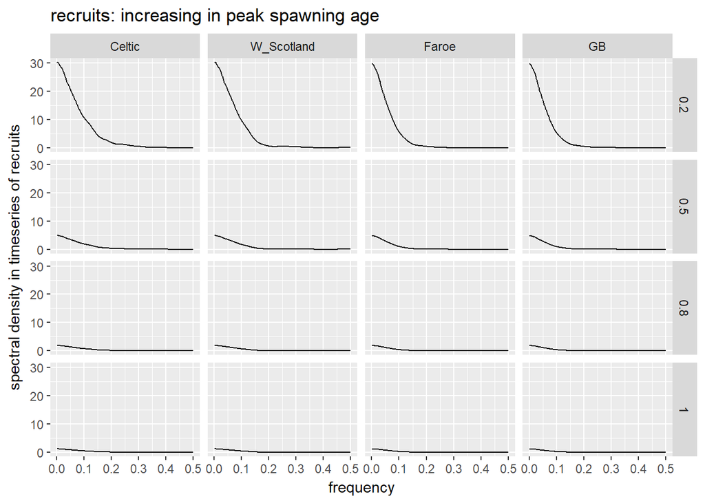

```r
#Merge temp, peak spawning age, CV of spawning biomass distribution into df
#May be useful for plotting
spec.out.df <- merge(spec.out.df,eigentable[c("codNames","temp")],all.x=TRUE)
spec.out.df <- merge(spec.out.df,eigentable[c("codNames","mode_age")],all.x=TRUE)
spec.out.df <- merge(spec.out.df,eigentable[c("codNames","sd_mode")],all.x=TRUE)
spec.out.df <- merge(spec.out.df,eigentable[c("codNames","max_ages")],all.x=TRUE)
spec.out.df <- merge(spec.out.df,eigentable[c("codNames","cvs_mode")],all.x=TRUE)
spec.out.df <- mutate(spec.out.df, codNames = reorder(codNames, mode_age))#order plots by peak spawning age

# Plot spectra
ggplot(spec.out.df[spec.out.df$out.type=="recruits" &
                     spec.out.df$codNames %in% c("Celtic","W_Scotland","Faroe","GB"),],  aes(x=freq,y=value)) +
  geom_line() +
  facet_grid(kval~codNames) +
  ggtitle("recruits: increasing in peak spawning age") +
  labs(y="spectral density in timeseries of recruits", x="frequency")
```

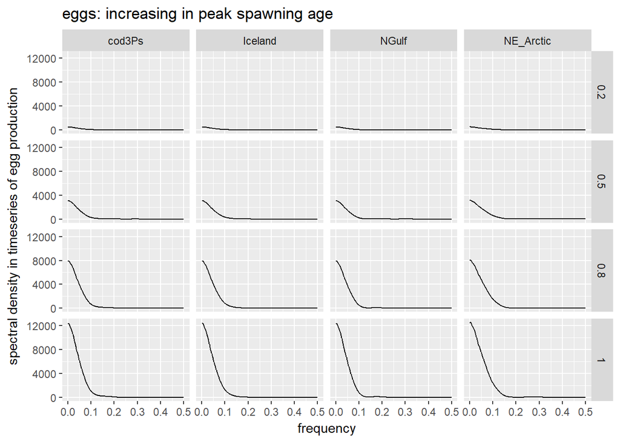

```r
# ---
ggplot(spec.out.df[spec.out.df$out.type=="eggs" &
                     spec.out.df$codNames %in% c("cod3Ps","Iceland","NGulf","NE_Arctic"),], aes(x=freq,y=value)) +
  geom_line() +
  facet_grid(kval~codNames) +
  ggtitle("eggs: increasing in peak spawning age") +
  labs(y="spectral density in timeseries of egg production", x="frequency")
```

```r
#pdf(file='C:/Users/provo/Documents/GitHub/popdy/cod_figures/spectrum_plots_v1.pdf', width=20, height=7)
#rp
#ep
#dev.off()
```

### 6. Calculating the AUC.

#### I calculate AUC for each pop at different k values, but don’t plot them yet. I figured I’ll tackle this once I’m confident the simulations are working right!

```r
# Eggs
aucList <- as.list(NA,length=length(codNames))
for (i in 1:length(codNames)) { #for pop i
  #subset df to pop i and eggs
  d <- spec.out.df[spec.out.df$codNames == codNames[i] & spec.out.df$out.type == "eggs",]
  auc <- rep(NA,length=length(ks)) #store auc for each k value here

  for (k in 1:length(ks)) { #for k value k
    #subset d to each k value, * by freq interval ... thank you Lauren!!
    auc[k] <- sum( d[d$kval == ks[k],]$value * min(d$freq) )} #close k loop

  #create df: auc, kval, codnames
  aucdf <- data.frame(cbind(auc,ks,rep(codNames[i],length=length(ks))))
  names(aucdf) <- c("auc","kval","codNames")
  aucList[[i]] <- aucdf #store this df in auc list
}
auc.df.eggs <- ldply(aucList, data.frame)
rm(i,k,d,auc,aucdf,aucList)

# Recruits - do same as above, but for recruits
aucList <- as.list(NA,length=length(codNames))
for (i in 1:length(codNames)) {
  d <- spec.out.df[spec.out.df$codNames == codNames[i] & spec.out.df$out.type == "recruits",]
  auc <- rep(NA,length=length(ks))
  for (k in 1:length(ks)) {
    auc[k] <- sum( d[d$kval == ks[k],]$value * min(d$freq) )}

  aucdf <- data.frame(cbind(auc,ks,rep(codNames[i],length=length(ks))))
  names(aucdf) <- c("auc","kval","codNames")
  aucList[[i]] <- aucdf
}
auc.df.recruits <- ldply(aucList, data.frame)
rm(i,k,d,auc,aucdf,aucList)
```

#### Somes notes on things that I’ve checked over the past few weeks based on conversations with Loo and Lauren. I cross-checked lambda1 between the plots I originally made for my AFS presentation (5 panel plots, lambda1 at different k values) with the modified Leslie matricies - they are the same (yay!). As k slope increases to 1, lambda1 also increases to 1.

[output not shown]